# Group_8 CLTV Analysis

### Group Members:

- Ronald (20BDA10)
- Rishab (20BDA26)
- Tanya (20BDA32)
- Ramya (20BDA33)
- Parvathy (20BDA38)
- Bharath (20BDA59)

### Why is CLTV important:

In today’s world growth of any business is driven by the amount of data a particular company possesses, through which effective decisions can be made to scale the business to greater heights. One such crucial strategies used by companies is to identify the customers who add more revenue to them in the long run. For example, bodybuilders and fitness freaks are primary consumers of meat and dairy products, they continuously invest in these products to reach their personal goals. This in turn poses as an advantage to meat and dairy industry to market their products better on different platforms to target their primary consumers. Retail sales can be maximized by just investing more resources on a meat shop located near a gym. Offers, discounts and other effective strategies can be applied by the business to generate more revenue and increase their profit. Hence, it becomes very crucial for a business to understand the value added by group of customers(who exhibit similar features) to grow their business. This is just an example of how customer lifetime value works with respect to a particular scenario. similar strategies can be applied by different industries.

```r
#Libraries in use:

library(readr)
library(dplyr)
library(ggplot2)
library(scales)

# Quick display of two cabapilities of GGally, to assess the distribution and correlation of variables
library(GGally)
library(superml)
library(mlbench)
library(mlr)
library(caret)
library(tidyverse)
library(caTools) # to split data into train and test
library(nnet)
library(class)
library(olsrr)
library(gmodels)
```

## 1. Loading the data:

|  | Customer | State | Customer.Lifetime.Value | Response | Coverage | Education | Effective.To.Date | EmploymentStatus | Gender | Income | Location.Code | Marital.Status | Monthly.Premium.Auto | Months.Since.Last.Claim | Months.Since.Policy.Inception | Number.of.Open.Complaints | Number.of.Policies | Policy.Type | Policy | Renew.Offer.Type | Sales.Channel | Total.Claim.Amount | Vehicle.Class | Vehicle.Size |
| --- | --- | --- | --- | --- | --- | --- | --- | --- | --- | --- | --- | --- | --- | --- | --- | --- | --- | --- | --- | --- | --- | --- | --- | --- |
| 1 | BU79786 | Washington | 2763.519 | No | Basic | Bachelor | 2011-02-24 | Employed | F | 56274 | Suburban | Married | 69 | 32 | 5 | 0 | 1 | Corporate Auto | Corporate L3 | Offer1 | Agent | 384.8111 | Two-Door Car | Medsize |
| 2 | QZ44356 | Arizona | 6979.536 | No | Extended | Bachelor | 2011-01-31 | Unemployed | F | 0 | Suburban | Single | 94 | 13 | 42 | 0 | 8 | Personal Auto | Personal L3 | Offer3 | Agent | 1131.4649 | Four-Door Car | Medsize |
| 3 | AI49188 | Nevada | 12887.432 | No | Premium | Bachelor | 2011-02-19 | Employed | F | 48767 | Suburban | Married | 108 | 18 | 38 | 0 | 2 | Personal Auto | Personal L3 | Offer1 | Agent | 566.4722 | Two-Door Car | Medsize |
| 4 | WW63253 | California | 7645.862 | No | Basic | Bachelor | 2011-01-20 | Unemployed | M | 0 | Suburban | Married | 106 | 18 | 65 | 0 | 7 | Corporate Auto | Corporate L2 | Offer1 | Call Center | 529.8813 | SUV | Medsize |
| 5 | HB64268 | Washington | 2813.693 | No | Basic | Bachelor | 2011-03-02 | Employed | M | 43836 | Rural | Single | 73 | 12 | 44 | 0 | 1 | Personal Auto | Personal L1 | Offer1 | Agent | 138.1309 | Four-Door Car | Medsize |
| 6 | OC83172 | Oregon | 8256.298 | Yes | Basic | Bachelor | 2011-01-25 | Employed | F | 62902 | Rural | Married | 69 | 14 | 94 | 0 | 2 | Personal Auto | Personal L3 | Offer2 | Web | 159.3830 | Two-Door Car | Medsize |

### Initial Analysis:

- We need to make the date format consistent.
- There seems to be no missing values in the data.
- Renew Offer Type, is it ordinal in nature by any chance?
  - The data doesn’t suggests the sane so we consider it to be a nominal.

## 2. EDA:

### 2.1 Gender

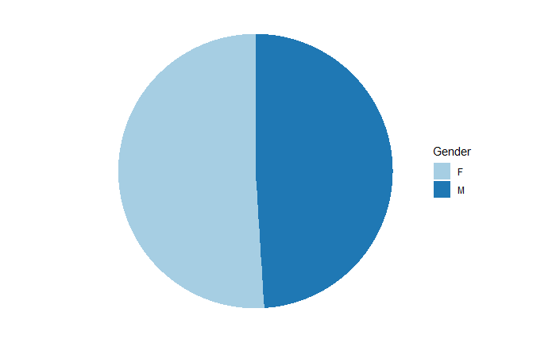

- The gender division is more or less equal. There are slightly more number of female customers.

### 2.2 Income

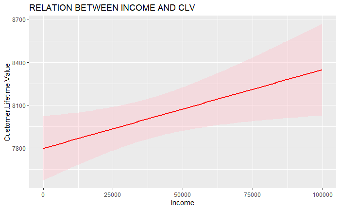

```r
ggplot(data=data, aes(x= Income, y=Customer.Lifetime.Value))+
  geom_smooth(method="lm", fill = "pink", color = "red")+ggtitle("RELATION BETWEEN INCOME AND CLV")
```

What kind of a relation does CLV have with income?

- Positive relationship.
- People who have more income have higher CLV.

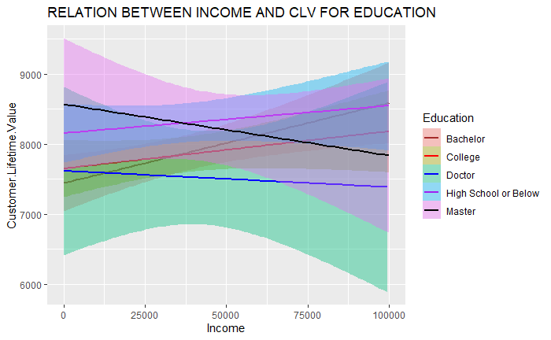

```r
ggplot(data=data, aes(x= Income, y=Customer.Lifetime.Value, color = Education, fill=Education))+
  geom_smooth(method="lm") +scale_color_manual(values = c("brown","red","blue","purple","black"))+ggtitle("RELATION BETWEEN INCOME AND CLV FOR EDUCATION")
```

Income and CLV relation for Education.

### 2.3 State:

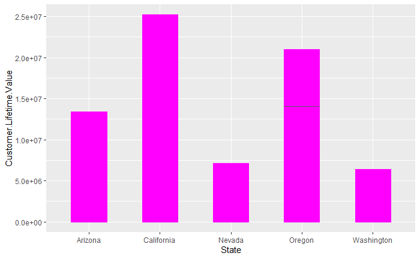

```r
# Ronald
## data distribution of customers across states with respect to their added value:
ggplot(data=data, aes(x=State,y=`Customer.Lifetime.Value`))+
  geom_bar(stat="identity", width=0.5,color='magenta')
```

```r
# Tanya
```

How does customer value vary across states?

- California and Oregan are seen to show more customer lifetime value compared to the other three states(nev,Washington,Ariona). A striking difference is that the former states differ from the latter states in demographic features. They are coastal states.

### 2.4 Location Code:

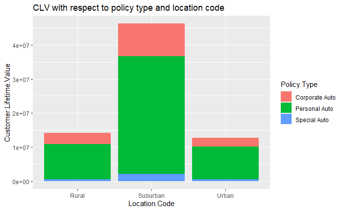

```r
## which policy plan is more popular with respect to the location?
ggplot(data, aes(fill=Policy.Type, y=Customer.Lifetime.Value, x=Location.Code)) +
  geom_bar(position="stack", stat="identity") +
  ggtitle("CLV with respect to policy type and location code")
```

- It is observed that suburban areas generate more CLTV when compared to rural and urban areas and most of the CLTV comes predominantly from personal auto policy type, However Corporate auto is seen to generate higher CLTV in suburban areas compared to rural and urban areas. The company can invest more marketing resources like ads and agents for customers in suburban areas and concentrate on the second best policy type(corporate auto) rather than on the steadily increasing policy personal auto.

### 2.5 Policy Type and Policy:

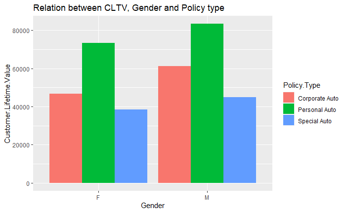

```r
ggplot(data, aes(fill=Policy.Type, y=Customer.Lifetime.Value, x=Gender)) +
  geom_bar(position="dodge", stat="identity")+
  ggtitle("Relation between CLTV, Gender and Policy type")
```

- Policy type has more males for all levels and Personal Auto has the most number of customers followed by Corporate and Special.

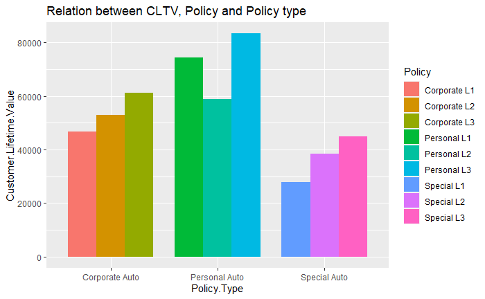

```r
ggplot(data, aes(x=Policy.Type,y=Customer.Lifetime.Value, fill = Policy)) +
  geom_bar(stat = "identity", width = 0.8, position = "dodge") +
  ggtitle("Relation between CLTV, Policy and Policy type")+
  labs(list(x = "Policy Type", y = "Customer Lifetime Value",fill = "Policy"))
```

For CLV, policy type and policy.

- For Corporate auto policy most of the people chose corporate L3.
- For Personal auto policy the highest selected policy was Personal L3 and Personal L1.
- For special auto policy the highest number was the special L3.

### 2.6 Employment status:

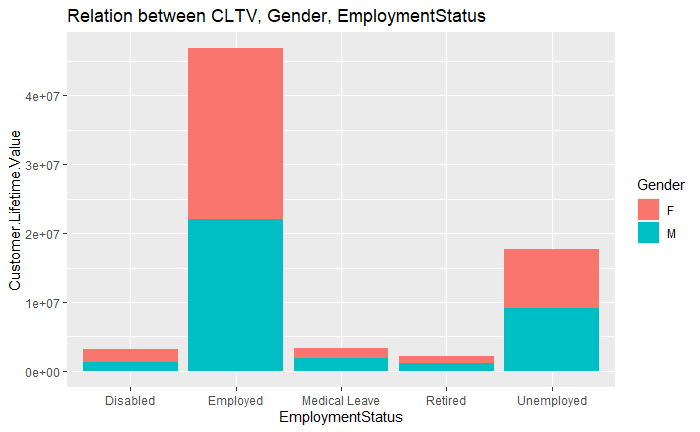

```r
ggplot(data, aes(fill=Gender, y=Customer.Lifetime.Value, x=EmploymentStatus)) +
  geom_bar(position="stack", stat="identity")+
  ggtitle("Relation between CLTV, Gender, EmploymentStatus")
```

- Employed and Unemployed contribute significantly.

### 2.7 Responses:

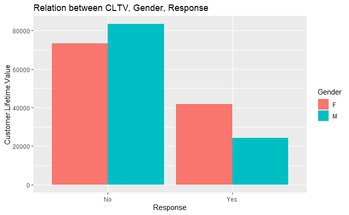

```r
ggplot(data, aes(fill=Gender, y=Customer.Lifetime.Value, x=Response)) +
  geom_bar(position="dodge", stat="identity")+
  ggtitle("Relation between CLTV, Gender, Response")
```

- Most yes comes from females, and no from men.

### 2.8 Coverage :

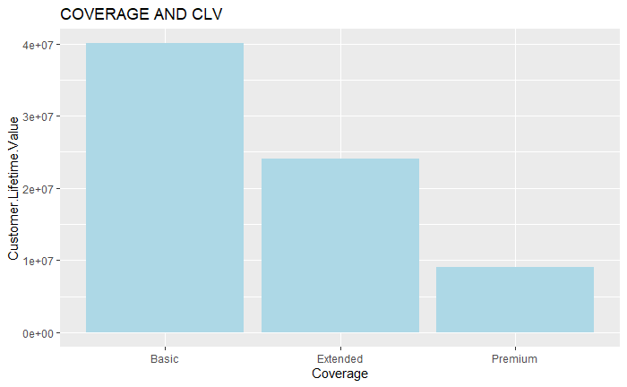

```r
ggplot(data,
       aes(Coverage,
           Customer.Lifetime.Value))+geom_col(fill="light blue")+ggtitle("COVERAGE AND CLV")
```

Coverage with High CLV?

- Basic coverage has high CLV and premium being the least

Does this have anything to do with more people taking up Basic coverage?

- Yes,more people purchased the basic coverage .

### 2.9 Number of Open complaints:

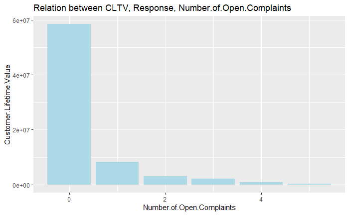

```r
ggplot(data, aes(y=Customer.Lifetime.Value, x=Number.of.Open.Complaints)) +
  geom_bar(position="stack", stat="identity", fill = 'light blue')+
  ggtitle("Relation between CLTV, Response, Number.of.Open.Complaints")
```

- The data has lower number of open complaints. Most of the open complain class has the level 0 depicting that there is maximum people have no open complains.

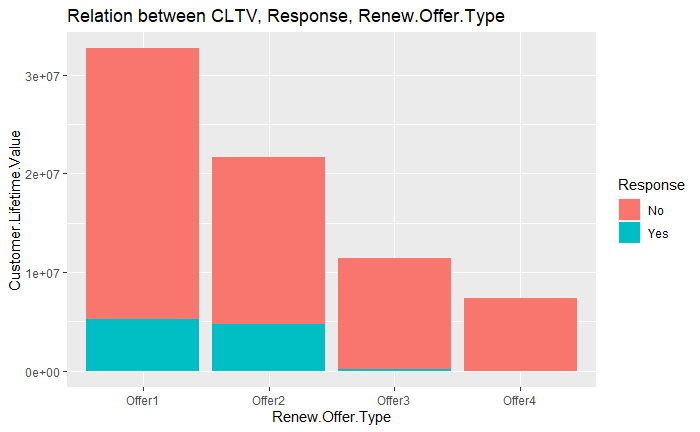

```r
ggplot(data, aes(fill=Response, y=Customer.Lifetime.Value, x=Renew.Offer.Type)) +
  geom_bar(position="stack", stat="identity")+
  ggtitle("Relation between CLTV, Response, Renew.Offer.Type")
```

- Offer 1 has the highest number of intakes and yes.
- Offer 2 comes in second and has the same number of yes.
- Offer 3 has next to null yes
- Offer 4 has no yes whatsoever.

### 2.11 Vehicle Size:

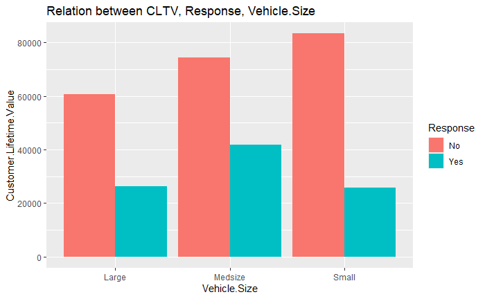

```r
ggplot(data, aes(fill=Response, y=Customer.Lifetime.Value, x=Vehicle.Size)) +
  geom_bar(position="dodge", stat="identity")+
  ggtitle("Relation between CLTV, Response, Vehicle.Size")
```

### 2.12 Sales Channel:

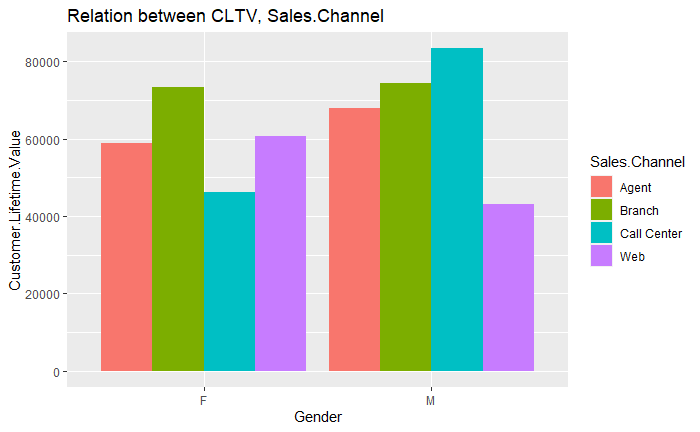

```r
ggplot(data, aes(fill=Sales.Channel, y=Customer.Lifetime.Value, x=Gender)) +
  geom_bar(position="dodge", stat="identity")+
  ggtitle("Relation between CLTV, Sales.Channel")
```

- The males seem to prefer more call center channel than women
- Branch seems to have a equal importance for both gender
- Females are more active on the web than men
- Agents seem to convince more men than women.

### 2.14 Marital Status and Vehicle Class:

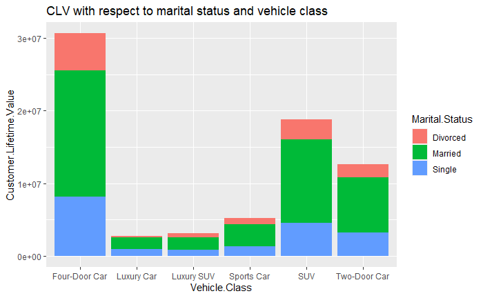

```r
ggplot(data, aes(fill=Marital.Status, y=Customer.Lifetime.Value, x=Vehicle.Class)) +
  geom_bar(position="stack", stat="identity") +
  ggtitle("CLV with respect to marital status and vehicle class")
```

- Two-Door Car, Four-Door Car and SUV show high customer lifetime value compared to the other three classes(‘Luxury SUV’, ‘Sports Car’,‘Luxury Car’). This tells us that most people from the states are buyers of vehicles from the former three classes. Most of them can’t afford a luxury vehicle. customers who own four-door cars in particular show an increase in CLV. Most of them can be assumed to have a family and hence the company can make a decision of approaching more people who are married and run a family in order to boost their revenue.

## 3 Outlier Analysis:

- These columns metioned below have outliers but we decided not to delete them as they might be informative.
  - CLTV
  - Monthly.Premium.Auto
  - Total.Claim.Amount

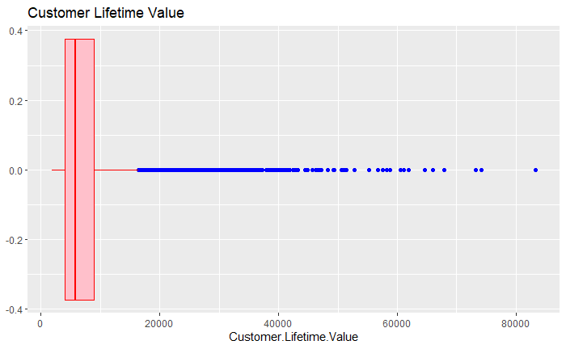

```r
# large number of outliers for CLTV
ggplot(data=data, aes(Customer.Lifetime.Value))+geom_boxplot(color="red",fill="pink",outlier.colour = "blue", notch=FALSE)+ggtitle("Customer Lifetime Value")
```

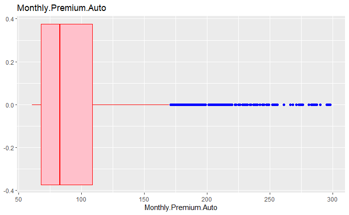

```r
# large number of outliers for Monthly.Premium.Auto
ggplot(data=data, aes(Monthly.Premium.Auto))+geom_boxplot(color="red",fill="pink",outlier.colour = "blue", notch=FALSE)+ggtitle("Monthly.Premium.Auto")
```

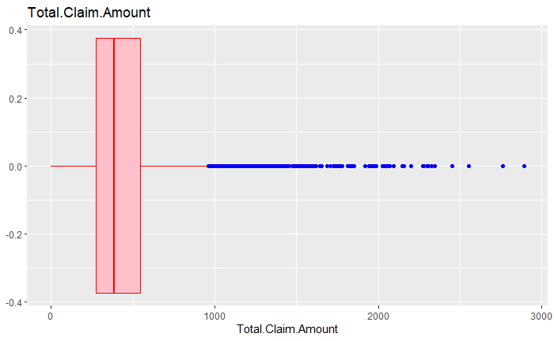

```r
# large number of outliers for Total.Claim.Amount
ggplot(data=data, aes(Total.Claim.Amount))+geom_boxplot(color="red",fill="pink",outlier.colour = "blue", notch=FALSE)+ggtitle("Total.Claim.Amount")
```

## 4. Multi-Linear Regression:

```r
# data transformation:
df <-  data
## Binning income, Monthly Premium Auto, Months Since Last Claim
df$inc_range <- cut(df$`Income`, breaks = c(-1,0,20000,40000,60000, 80000, 100000), labels = c(0,1,2,3,4,5),ordered = TRUE)
df$pre_auto_range <- cut(df$`Monthly.Premium.Auto`,  breaks = seq(60, 300, by = 48), labels = c(0,1,2,3,4),ordered = TRUE)
df$mnt_lst_claim <- cut(df$`Months.Since.Last.Claim`, breaks = 6, labels = c(0,1,2,3,4,5),ordered = TRUE)

## Label encoding
df$State = factor(df$State, level = c("Arizona","California","Nevada","Oregon","Washington"),
 labels = c(1,2,3,4,5))
df$Gender = factor(df$Gender, level =c("F","M"), labels = c(1,2))
df$Marital.Status = factor(df$Marital.Status, level =c("Single","Married","Divorced"), labels = c(1,2,3))

df$Policy.Type = factor(df$Policy.Type, level =c("Corporate Auto","Personal Auto","Special Auto"),
 labels = c(1,2,3))

df$Response = factor(df$Response, level =c("No","Yes"), labels = c(0,1))

df$EmploymentStatus = factor(df$EmploymentStatus, level =c("Unemployed","Employed","Medical Leave",
 "Disabled","Retired"), labels = c(1,2,3,4,5))

df$Coverage = factor(df$Coverage, level = c("Basic","Extended","Premium"), labels = c(1,2,3))

df$Education = factor(df$Education, level =c("High School or Below","College","Bachelor","Master","Doctor"),
labels = c(1,2,3,4,5))

df$Location.Code = factor(df$Location.Code, level=c("Rural","Suburban","Urban"), labels = c(1,2,3))

df$Sales.Channel = factor(df$Sales.Channel, level =c("Agent","Branch","Call Center","Web"),
labels =c(1,2,3,4))

df$Vehicle.Size = factor(df$Vehicle.Size, level =c("Small","Medsize","Large"), labels = c(1,2,3))

df$Vehicle.Class = factor(df$Vehicle.Class, level =c("Two-Door Car","Four-Door Car","SUV","Sports Car",
 "Luxury Car", "Luxury SUV"), labels = c(1,2,3,4,5,6))

df$Renew.Offer.Type = factor(df$Renew.Offer.Type, level =c("Offer1", "Offer2","Offer3","Offer4"),
labels = c(1,2,3,4) )

df$Policy = factor(df$Policy, level =c("Corporate L3","Personal L3","Corporate L2","Personal L1",
 "Special L2","Corporate L1","Personal L2","Special L1","Special L3"),labels = c(1,2,3,4,5,6,7,8,9))
```

#### Changing column name in R standard format

```r
names(df)[names(df) == "Customer.Lifetime.Value"] <- "clv"
names(df)[names(df) == "Location.Code"] <- "lc"
names(df)[names(df) == "Monthly.Premium.Auto"] <- "mpa"
names(df)[names(df) == "Marital.Status"] <- "marital_status"
names(df)[names(df) == "Months.Since.Last.Claim"] <- "mnths_since_lst_claim"
names(df)[names(df) == "Months.Since.Policy.Inception"] <- "mnths_policy_inc"
names(df)[names(df) == "Number.of.Open.Complaints"] <- "open_comp"
names(df)[names(df) == "Number.of.Policies"] <- "no_policy"
names(df)[names(df) == "Policy.Type"] <- "policy_type"
names(df)[names(df) == "Renew.Offer.Type"] <- "renew_offer_type"
names(df)[names(df) == "Sales.Channel"] <- "sales_ch"
names(df)[names(df) == "Total.Claim.Amount"] <- "tca"
names(df)[names(df) == "Vehicle.Class"] <- "vec_class"
names(df)[names(df) == "Vehicle.Size"] <- "vec_size"

str(df)
```

```
'data.frame':   9134 obs. of  27 variables:
 $ Customer             : chr  "BU79786" "QZ44356" "AI49188" "WW63253" ...
 $ State                : Factor w/ 5 levels "1","2","3","4",..: 5 1 3 2 5 4 4 1 4 4 ...
 $ clv                  : num  2764 6980 12887 7646 2814 ...
 $ Response             : Factor w/ 2 levels "0","1": 1 1 1 1 1 2 2 1 2 1 ...
 $ Coverage             : Factor w/ 3 levels "1","2","3": 1 2 3 1 1 1 1 3 1 2 ...
 $ Education            : Factor w/ 5 levels "1","2","3","4",..: 3 3 3 3 3 3 2 4 3 2 ...
 $ Effective.To.Date    : Date, format: "2011-02-24" "2011-01-31" "2011-02-19" "2011-01-20" ...
 $ EmploymentStatus     : Factor w/ 5 levels "1","2","3","4",..: 2 1 2 1 2 2 2 1 3 2 ...
 $ Gender               : Factor w/ 2 levels "1","2": 1 1 1 2 2 1 1 2 2 1 ...
 $ Income               : int  56274 0 48767 0 43836 62902 55350 0 14072 28812 ...
 $ lc                   : Factor w/ 3 levels "1","2","3": 2 2 2 2 1 1 2 3 2 3 ...
 $ marital_status       : Factor w/ 3 levels "1","2","3": 2 1 2 2 1 2 2 1 3 2 ...
 $ mpa                  : int  69 94 108 106 73 69 67 101 71 93 ...
 $ mnths_since_lst_claim: int  32 13 18 18 12 14 0 0 13 17 ...
 $ mnths_policy_inc     : int  5 42 38 65 44 94 13 68 3 7 ...
 $ open_comp            : int  0 0 0 0 0 0 0 0 0 0 ...
 $ no_policy            : int  1 8 2 7 1 2 9 4 2 8 ...
 $ policy_type          : Factor w/ 3 levels "1","2","3": 1 2 2 1 2 2 1 1 1 3 ...
 $ Policy               : Factor w/ 9 levels "1","2","3","4",..: 1 2 2 3 4 2 1 1 1 5 ...
 $ renew_offer_type     : Factor w/ 4 levels "1","2","3","4": 1 3 1 1 1 2 1 1 1 2 ...
 $ sales_ch             : Factor w/ 4 levels "1","2","3","4": 1 1 1 3 1 4 1 1 1 2 ...
 $ tca                  : num  385 1131 566 530 138 ...
 $ vec_class            : Factor w/ 6 levels "1","2","3","4",..: 1 2 1 3 2 1 2 2 2 2 ...
 $ vec_size             : Factor w/ 3 levels "1","2","3": 2 2 2 2 2 2 2 2 2 2 ...
 $ inc_range            : Ord.factor w/ 6 levels "0"<"1"<"2"<"3"<..: 4 1 4 1 4 5 4 1 2 3 ...
 $ pre_auto_range       : Ord.factor w/ 5 levels "0"<"1"<"2"<"3"<..: 1 1 1 1 1 1 1 1 1 1 ...
 $ mnt_lst_claim        : Ord.factor w/ 6 levels "0"<"1"<"2"<"3"<..: 6 3 4 4 3 3 1 1 3 3 ...
```

#### drop of some columns to get information gain of each variable in terms of target variable clv

```r
d = c("mnt_lst_claim","pre_auto_range","pre_auto_range","inc_range","clv_range","edu","edu_encode","Effective.To.Date","Customer")
df <- df[ , !(names(df) %in% d)]
str(df)
```

```
'data.frame':   9134 obs. of  22 variables:
 $ State                : Factor w/ 5 levels "1","2","3","4",..: 5 1 3 2 5 4 4 1 4 4 ...
 $ clv                  : num  2764 6980 12887 7646 2814 ...
 $ Response             : Factor w/ 2 levels "0","1": 1 1 1 1 1 2 2 1 2 1 ...
 $ Coverage             : Factor w/ 3 levels "1","2","3": 1 2 3 1 1 1 1 3 1 2 ...
 $ Education            : Factor w/ 5 levels "1","2","3","4",..: 3 3 3 3 3 3 2 4 3 2 ...
 $ EmploymentStatus     : Factor w/ 5 levels "1","2","3","4",..: 2 1 2 1 2 2 2 1 3 2 ...
 $ Gender               : Factor w/ 2 levels "1","2": 1 1 1 2 2 1 1 2 2 1 ...
 $ Income               : int  56274 0 48767 0 43836 62902 55350 0 14072 28812 ...
 $ lc                   : Factor w/ 3 levels "1","2","3": 2 2 2 2 1 1 2 3 2 3 ...
 $ marital_status       : Factor w/ 3 levels "1","2","3": 2 1 2 2 1 2 2 1 3 2 ...
 $ mpa                  : int  69 94 108 106 73 69 67 101 71 93 ...
 $ mnths_since_lst_claim: int  32 13 18 18 12 14 0 0 13 17 ...
 $ mnths_policy_inc     : int  5 42 38 65 44 94 13 68 3 7 ...
 $ open_comp            : int  0 0 0 0 0 0 0 0 0 0 ...
 $ no_policy            : int  1 8 2 7 1 2 9 4 2 8 ...
 $ policy_type          : Factor w/ 3 levels "1","2","3": 1 2 2 1 2 2 1 1 1 3 ...
 $ Policy               : Factor w/ 9 levels "1","2","3","4",..: 1 2 2 3 4 2 1 1 1 5 ...
 $ renew_offer_type     : Factor w/ 4 levels "1","2","3","4": 1 3 1 1 1 2 1 1 1 2 ...
 $ sales_ch             : Factor w/ 4 levels "1","2","3","4": 1 1 1 3 1 4 1 1 1 2 ...
 $ tca                  : num  385 1131 566 530 138 ...
 $ vec_class            : Factor w/ 6 levels "1","2","3","4",..: 1 2 1 3 2 1 2 2 2 2 ...
 $ vec_size             : Factor w/ 3 levels "1","2","3": 2 2 2 2 2 2 2 2 2 2 ...
```

#### Covert data in required format using makeRegrTask()

```r
con_df <- makeRegrTask(data = df, target = "clv")
```

#### Generate information gain

```r
fv = generateFilterValuesData(con_df, method = "FSelectorRcpp_information.gain")
```

```
Dependent variable is a numeric! It will be converted to factor with simple factor(y). We do not discretize dependent variable in FSelectorRcpp by default! You can choose equal frequency binning discretization by setting equal argument to TRUE.
```

```r
fv
```

```
FilterValues:
Task: df
```

| name | type | filter | value |
| --- | --- | --- | --- |
| Policy | factor | FSelectorRcpp_information.gain | 1.5350658 |
| Education | factor | FSelectorRcpp_information.gain | 1.4061975 |
| sales_ch | factor | FSelectorRcpp_information.gain | 1.3217726 |
| State | factor | FSelectorRcpp_information.gain | 1.3196422 |
| vec_class | factor | FSelectorRcpp_information.gain | 1.2961292 |
| renew_offer_type | factor | FSelectorRcpp_information.gain | 1.2655045 |
| EmploymentStatus | factor | FSelectorRcpp_information.gain | 1.0321851 |
| marital_status | factor | FSelectorRcpp_information.gain | 0.9539355 |
| lc | factor | FSelectorRcpp_information.gain | 0.9115115 |
| Coverage | factor | FSelectorRcpp_information.gain | 0.8798218 |

[output cut: 11 more lines]

#### Split data into train and test data for model

```r
set.seed(1001)
sample <- sample.split(df$clv, SplitRatio = 0.80)
train = subset(df, sample == TRUE)
test = subset(df, sample == FALSE)
```

#### 1st model using simple linear regression on all variable

```r
# MLR model
mlrmodel <- lm(clv~., train)
mlrmodel
```

```
Call:
lm(formula = clv ~ ., data = train)

Coefficients:
          (Intercept)                 State2                 State3                 State4                 State5
            7.163e+02             -2.289e+01              2.705e+01             -3.031e+01              8.150e+01
            Response1              Coverage2              Coverage3             Education2             Education3
           -2.365e+02             -2.398e+01             -2.710e+02             -2.955e+02             -3.914e+02
           Education4             Education5      EmploymentStatus2      EmploymentStatus3      EmploymentStatus4
           -2.224e+02             -4.589e+02              5.062e+02              7.792e+01             -1.662e+02
    EmploymentStatus5                Gender2                 Income                    lc2                    lc3
            2.961e+02             -8.932e+01              1.779e-03             -1.103e+02              5.382e+01
      marital_status2        marital_status3                    mpa  mnths_since_lst_claim       mnths_policy_inc
            3.623e+02              4.368e+02              7.575e+01              1.242e+01             -2.259e+00
            open_comp              no_policy           policy_type2           policy_type3                Policy2
           -3.035e+02              4.391e+01              3.165e+02              1.018e+03             -3.982e+01
              Policy3                Policy4                Policy5                Policy6                Policy7
           -2.551e+02             -7.021e+01             -1.605e+02              7.168e+02                     NA
              Policy8                Policy9      renew_offer_type2      renew_offer_type3      renew_offer_type4
           -5.540e+01                     NA             -1.005e+03             -3.417e+02             -1.310e+03
            sales_ch2              sales_ch3              sales_ch4                    tca             vec_class2
            3.430e+02              4.836e+02              2.151e+01             -1.184e-01             -1.021e+02
           vec_class3             vec_class4             vec_class5             vec_class6              vec_size2
            3.624e+02              9.495e+02              5.272e+02             -1.610e+01              1.521e+01
            vec_size3
           -3.924e+02
```

#### Model assessment

```r
summary(mlrmodel)
```

```
Call:
lm(formula = clv ~ ., data = train)

Residuals:
   Min     1Q Median     3Q    Max
-12983  -3324  -1320    822  62929

Coefficients: (2 not defined because of singularities)
                        Estimate Std. Error t value Pr(>|t|)
(Intercept)            7.163e+02  8.954e+02   0.800 0.423753
State2                -2.289e+01  2.144e+02  -0.107 0.914960
State3                 2.705e+01  2.934e+02   0.092 0.926537
State4                -3.031e+01  2.213e+02  -0.137 0.891081
State5                 8.150e+01  3.045e+02   0.268 0.788932
Response1             -2.365e+02  2.320e+02  -1.020 0.307989
Coverage2             -2.398e+01  2.802e+02  -0.086 0.931783
Coverage3             -2.710e+02  5.922e+02  -0.458 0.647252
Education2            -2.955e+02  1.964e+02  -1.505 0.132356
Education3            -3.914e+02  1.953e+02  -2.004 0.045093 *
Education4            -2.224e+02  3.001e+02  -0.741 0.458645
Education5            -4.589e+02  4.124e+02  -1.113 0.265881
EmploymentStatus2      5.062e+02  3.075e+02   1.646 0.099709 .
EmploymentStatus3      7.792e+01  3.868e+02   0.201 0.840345
EmploymentStatus4     -1.662e+02  3.993e+02  -0.416 0.677180
EmploymentStatus5      2.961e+02  4.795e+02   0.618 0.536830
Gender2               -8.932e+01  1.494e+02  -0.598 0.549812
Income                 1.779e-03  4.356e-03   0.408 0.683010
lc2                   -1.103e+02  2.960e+02  -0.373 0.709482
lc3                    5.382e+01  2.716e+02   0.198 0.842932
marital_status2        3.623e+02  1.940e+02   1.868 0.061869 .
marital_status3        4.368e+02  2.538e+02   1.721 0.085272 .
mpa                    7.575e+01  1.130e+01   6.704 2.18e-11 ***
mnths_since_lst_claim  1.242e+01  7.385e+00   1.682 0.092639 .
mnths_policy_inc      -2.259e+00  2.681e+00  -0.843 0.399439
open_comp             -3.035e+02  8.291e+01  -3.660 0.000254 ***
no_policy              4.391e+01  3.149e+01   1.395 0.163185
policy_type2           3.165e+02  2.695e+02   1.174 0.240362
policy_type3           1.018e+03  6.273e+02   1.622 0.104822
Policy2               -3.982e+01  1.968e+02  -0.202 0.839678
Policy3               -2.551e+02  3.603e+02  -0.708 0.478950
```

[output cut: 11 more lines]

```
sales_ch4              2.151e+01  2.316e+02   0.093 0.925991
tca                   -1.184e-01  5.312e-01  -0.223 0.823681
vec_class2            -1.021e+02  1.924e+02  -0.531 0.595518
vec_class3             3.624e+02  5.281e+02   0.686 0.492579
vec_class4             9.495e+02  6.014e+02   1.579 0.114439
vec_class5             5.272e+02  1.557e+03   0.339 0.734855
vec_class6            -1.610e+01  1.560e+03  -0.010 0.991765
vec_size2              1.521e+01  1.950e+02   0.078 0.937850
vec_size3             -3.924e+02  2.869e+02  -1.368 0.171465
---
Signif. codes:  0 ‘***’ 0.001 ‘**’ 0.01 ‘*’ 0.05 ‘.’ 0.1 ‘ ’ 1

Residual standard error: 6312 on 7258 degrees of freedom
Multiple R-squared:  0.1701,    Adjusted R-squared:  0.1646
F-statistic:    31 on 48 and 7258 DF,  p-value: < 2.2e-16
```

#### Plot the model report

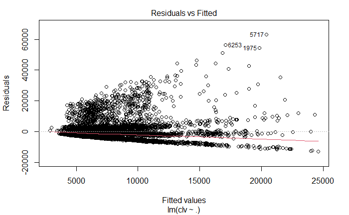

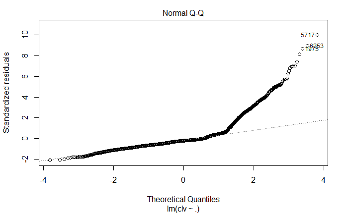

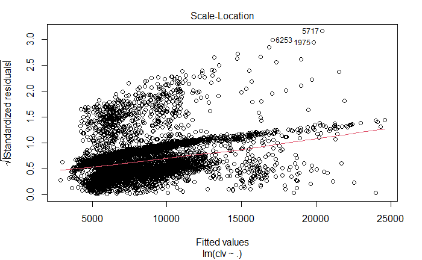

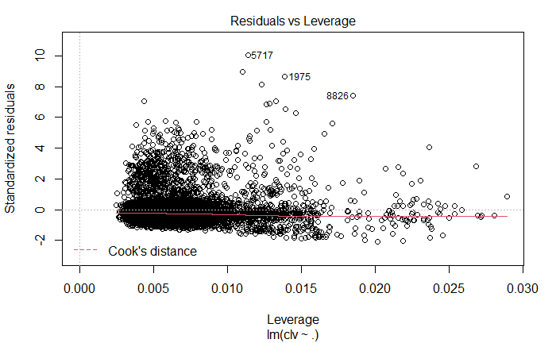

```r
plot(mlrmodel)
```

#### Analysis of variance

```r
anova(mlrmodel)
```

```
Analysis of Variance Table

Response: clv
                        Df     Sum Sq    Mean Sq   F value    Pr(>F)
State                    4 2.3033e+07 5.7582e+06    0.1445 0.9654539
Response                 1 4.1205e+07 4.1205e+07    1.0343 0.3091875
Coverage                 2 9.6643e+09 4.8321e+09  121.2923 < 2.2e-16 ***
Education                4 1.7218e+08 4.3046e+07    1.0805 0.3642652
EmploymentStatus         4 4.6868e+08 1.1717e+08    2.9411 0.0192575 *
Gender                   1 1.5782e+07 1.5782e+07    0.3961 0.5291058
Income                   1 3.9485e+06 3.9485e+06    0.0991 0.7529079
lc                       2 2.4540e+07 1.2270e+07    0.3080 0.7349279
marital_status           2 1.1934e+08 5.9671e+07    1.4978 0.2236884
mpa                      1 4.5199e+10 4.5199e+10 1134.5515 < 2.2e-16 ***
mnths_since_lst_claim    1 1.1471e+08 1.1471e+08    2.8795 0.0897588 .
mnths_policy_inc         1 4.0572e+05 4.0572e+05    0.0102 0.9196203
open_comp                1 4.3684e+08 4.3684e+08   10.9652 0.0009329 ***
no_policy                1 1.7592e+08 1.7592e+08    4.4158 0.0356413 *
policy_type              2 2.0105e+08 1.0053e+08    2.5233 0.0802637 .
Policy                   6 1.6074e+08 2.6789e+07    0.6724 0.6719870
renew_offer_type         3 1.6942e+09 5.6474e+08   14.1758  3.29e-09 ***
sales_ch                 3 2.9522e+08 9.8408e+07    2.4702 0.0599911 .
tca                      1 6.8844e+06 6.8844e+06    0.1728 0.6776408
vec_class                5 3.4793e+08 6.9586e+07    1.7467 0.1203273
vec_size                 2 1.1102e+08 5.5508e+07    1.3933 0.2483163
Residuals             7258 2.8915e+11 3.9839e+07
---
Signif. codes:  0 ‘***’ 0.001 ‘**’ 0.01 ‘*’ 0.05 ‘.’ 0.1 ‘ ’ 1
```

```r
# Prediction on test data
clvpred <- predict(mlrmodel, test)
```

```
prediction from a rank-deficient fit may be misleading
```

```r
# cross-validation
mse <- mean((test$clv - clvpred)^2)
rmse <- sqrt(mse)
rmse
```

```
[1] 6165.19
```

```r
prederror <- rmse/mean(test$clv)
prederror
```

```
[1] 0.7855618
```

#### 2nd appraoach model 2 Using Stepwise regression

```
Factor variables are omitted in plot
```

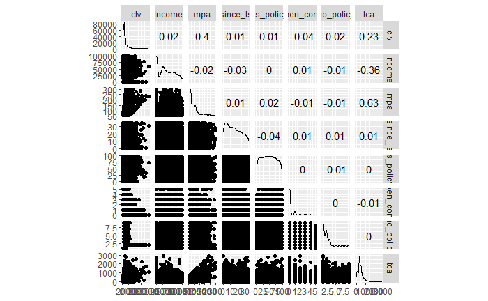

```r
ggscatmat(df, columns = 1:ncol(df), corMethod = "pearson")
```

```r
## stepwise model
ols_step_both_p(mlrmodel, pent = 0.1, prem = 0.3, details = FALSE)
```

```
Note: model has aliased coefficients
      sums of squares computed by model comparison
Note: model has aliased coefficients
      sums of squares computed by model comparison
```

```
                                       Stepwise Selection Summary
--------------------------------------------------------------------------------------------------------
                                  Added/                   Adj.
Step          Variable           Removed     R-Square    R-Square     C(p)          AIC          RMSE
--------------------------------------------------------------------------------------------------------
   1             mpa             addition       0.157       0.157    71.6110    148684.7269    6341.7952
   2      renew_offer_type       addition       0.160       0.160    43.6380    148660.9687    6330.1946
   3           Income            addition       0.162       0.162    28.7560    148646.1540    6323.3484
   4          open_comp          addition       0.164       0.163    17.2970    148634.7204    6317.9712
   5          vec_class          addition       0.165       0.164     6.9290    148632.3544    6314.7903
   6          sales_ch           addition       0.166       0.164     1.3940    148630.8106    6312.8296
   7       marital_status        addition       0.167       0.165    -1.9720    148629.4329    6311.3726
   8         policy_type         addition       0.167       0.165    -5.1820    148628.2080    6309.9821
   9    mnths_since_lst_claim    addition       0.168       0.165    -6.4440    148626.9350    6309.0019
--------------------------------------------------------------------------------------------------------
```

```r
stp_s <-ols_step_both_p(mlrmodel, details=FALSE)
```

```
Note: model has aliased coefficients
      sums of squares computed by model comparison
Note: model has aliased coefficients
      sums of squares computed by model comparison
```

#### Final model using stepwise

```r
summary(stp_s$model)
```

```
Call:
lm(formula = paste(response, "~", paste(preds, collapse = " + ")),
    data = l)

Residuals:
   Min     1Q Median     3Q    Max
-13069  -3376  -1195    869  63139

Coefficients:
                        Estimate Std. Error t value Pr(>|t|)
(Intercept)            5.848e+02  4.604e+02   1.270 0.204116
mpa                    7.174e+01  4.481e+00  16.011  < 2e-16 ***
renew_offer_type2     -1.001e+03  1.814e+02  -5.515 3.60e-08 ***
renew_offer_type3     -2.696e+02  2.215e+02  -1.217 0.223580
renew_offer_type4     -1.239e+03  2.582e+02  -4.798 1.63e-06 ***
Income                 8.919e-03  2.602e-03   3.428 0.000611 ***
open_comp             -2.994e+02  8.263e+01  -3.623 0.000294 ***
vec_class2            -7.253e+01  1.919e+02  -0.378 0.705496
vec_class3             5.247e+02  3.024e+02   1.735 0.082727 .
vec_class4             1.130e+03  4.064e+02   2.780 0.005445 **
vec_class5             9.776e+02  8.269e+02   1.182 0.237131
vec_class6             4.370e+02  8.332e+02   0.525 0.599915
sales_ch2              3.446e+02  1.841e+02   1.872 0.061283 .
sales_ch3              4.795e+02  2.078e+02   2.308 0.021046 *
sales_ch4              3.102e+01  2.300e+02   0.135 0.892733
marital_status2        4.041e+02  1.815e+02   2.227 0.026005 *
marital_status3        4.161e+02  2.432e+02   1.711 0.087186 .
policy_type2           2.302e+02  1.798e+02   1.280 0.200584
policy_type3           8.937e+02  3.985e+02   2.243 0.024939 *
mnths_since_lst_claim  1.328e+01  7.351e+00   1.807 0.070825 .
---
Signif. codes:  0 ‘***’ 0.001 ‘**’ 0.01 ‘*’ 0.05 ‘.’ 0.1 ‘ ’ 1

Residual standard error: 6309 on 7287 degrees of freedom
Multiple R-squared:  0.1675,    Adjusted R-squared:  0.1654
F-statistic: 77.19 on 19 and 7287 DF,  p-value: < 2.2e-16
```